# Ontwikkelingen huizenmarkt

Huizenprijzen en transactievolumes in Nederland

Merijn van Miltenburg

18/04/2021

# 1 Inleiding

De volksbank is het moederbedrijf van ASN, SNS, BLG en Regiobank. Als de vierde bank van Nederland, financiert de volksbank hypotheken, beheert ze spaargeld en biedt de bank klanten een betaalrekening. Binnen de afdeling Financial Markets van de Volksbank, hebben de macro-economen van de Volksbank als taak de toestand in de economie te monitoren en toe te lichten aan directie en beleidsmakers. Een belangrijk onderdeel daarvan heeft betrekking met de ontwikkeling van de hypotheekmarkt in Nederland. De huizenmarkt is een belangrijke factor in de beleidsontwikkeling van de bank, met betrekking tot de hypotheekproductie.

Voor deze analyse is de PPDAC cyclus (Problem, Plan, Data, Analysis, and Conclusions) gevolgd; een methode voor het uitvoeren van statistisch onderzoek (MacKay & Oldford, 2000). In deze studie is gebruik gemaakt van R (R Core Team, 2021) voor analyse en presentatie van de data.

# 2 Probleemstelling

Uit het overleg met de macro-economen is de vraag naar voren gekomen of een beter voorspellend model kan worden ontwikkeld voor de huizenmarkt in Nederland. Is het mogelijk om modellen te ontwikkelen die de huizenprijs op middellange termijn voorspelt en het aantal transacties op de huizenmarkt op middellange termijn voorspelt?

Vanuit de Volksbank is in het verleden al eerder statistisch onderzoek gedaan naar deze verbanden. Voor de huizenprijzen is eerder gekeken naar een verband tussen huizenprijzen en de werkgelegenheid, lonen, BBP (Bruto Binnenlands Product) en rente. In deze exploratie wordt gekeken naar mogelijke factoren die effect hebben op de marktprijs. De hier genoemde factoren zullen hierbij worden meegenomen. Dit lijdt tot de volgende onderzoeksvraag:

Welke factoren spelen een belangrijke rol in het bepalen van de huizenprijzen en transactie volumes op een termijn van 2 tot 5 jaar?

Voor beantwoording van deze vraag wordt eerst gekeken in hoeverre de huizenprijzen worden bepaald door wijzigingen in vraag en aanbod. Daarna wordt verder ingegaan op de factoren die op langere termijn de huizenprijzen beïnvloeden en wordt gekeken of hier voorspellende waarde in zit. Vervolgens wordt gekeken naar de transactievolumes. Welke factoren spelen een belangrijke rol in het bepalen van de transactievolumes op een termijn van 2 tot 5 jaar? Voor het aantal transacties op de lange termijn wordt een verband verondersteld met het aantal huishoudens.

# 3 Plan

Om een begin te maken met het beantwoorden van deze vragen zijn een aantal gesprekken gevoerd met specialisten bij de Volksbank. Aanvullend is een korte literatuurstudie uitgevoerd naar de factoren die op lange termijn de prijsstelling beïnvloeden. Het CBS publiceert vrij veel over de prijsontwikkeling van bestaande woningen, nieuwe woningen en de stand van de economie (CBS, 2016), (CBS, 2020),(“Monitor koopwoningmarkt,” 2020),(Minister Wonen en Rijksdienst, 2016),(Groot, Vogt, Van der Wiel, & Van Dijk, 2018). De Socrates modellen (Kenneth Gopal, Gerard van Leeuwen, David Omtzigt, 2020), en het primos onderzoek (Research, 2020), (Léon Groenemeijer, Kenneth Gopal, 2020) sluiten goed aan bij de vraagstelling van dit onderzoek.

Vraag en aanbod worden bepaald door:

Vraag woningen:

- Aantal huishoudens
- Demografie (omvang en samenstelling huishoudens)
- (Arbeids-)migratie

Aanbod woningen:

- Woningvoorraad
- Nieuwbouw/ Sloop
- Bouwkosten
- Beschikbaarheid bouwlocaties
- Ruimtelijkeordeningsbeleid

Daarna is verder ingegaan op de factoren die van invloed zijn bij de prijsontwikkeling op de woningmarkt.

Indicatoren prijsontwikkeling woningmarkt

- Gem. huizenprijzen afgelopen perioden (prijsindex)
- Besteedbaar Inkomen
- Particulier vermogen
- Werkloosheid
- Rentestanden
- Consumentenvertrouwen
- Fiscale behandeling, subsidies
- Toegang tot krediet
- Financiering hypotheek of eigen geld
- Voorkeuren van kopers

Gegevens over de verhouding tussen huur en koopprijzen, het aantal te koop staande huizen, de gem. tijd dat een woning te koop staat en de prijsverschillen tussen aanbodprijs en transactieprijs zeggen iets over de mate van oververhitting van de markt (Groot et al., 2018). In deze studie is echter onvoldoende data beschikbaar om hier een tijdsanalyse over uit te voeren. Deze data is verder buiten deze analyse gelaten.

Het aantal transacties wordt verondersteld met name bepaald te worden door het aantal huishoudens. Daarnaast kan door krapte op de woningmarkt een schaarste ontstaan waardoor de woningmarkt ‘op slot’ geraakt. Het consumentenvertrouwen speelt hierbij ook een belangrijke rol.

Indicatoren aantal transacties

- Aanbod huizen
- Toegang tot krediet
- Werkloosheid
- Consumentenvertrouwen
- Verschil aanbodprijs en transactieprijs
- Aantal dagen aangeboden

# 4 Data

De gewenste informatie is opgevraagd bij de statistici (via Reuters Datastream) en later aangevuld met open data van het CBS (Statline). Voor het inlezen van de (spreadsheet) Reutersdata zijn een aantal functies ontwikkeld. Om de data van het CBS gemakkelijker in te kunnen lezen is een routine ontwikkeld die aan de hand van metadata de gevraagde data inleest. Routines voor het lezen en opschonen van de data, zijn opgeslagen in separate R files.

De data die via die routines is opgehaald en opgeschoond is tussentijds opgeslagen in Rdata formaat - en kan voor de analyse hierdoor direct worden ingelezen. Op deze wijze is een scheiding aangebracht tussen de data-acquisitie en de analyse van de resultaten.

```r
library (tidyverse)          # Tidyverse utilities (Wickham et al. 2019)

library (here)               # here: A Simpler Way to Find Your Files (Müller 2020))
library (lubridate)          # Dates and Times Made Easy (Grolemund, Wickham 2011))
library (reshape2)           # Reshaping Data (Hadley Wickham 2007)
library (knitr)              # A General-Purpose Package for Dynamic Report Generation (Xie 2021)
library (kableExtra)         # Construct Complex Table with 'kable' and Pipe Syntax(Zhu 2021)
library (viridis)            # Default Color Maps from 'matplotlib' (Garnier 2018)
library (forcats)            # Tools for Working with Categorical Variables (Factors) (Wickham 2021)
library (forecast)           # Forecasting functions for time series and linear models (Hyndman et al. 2021)
library (fpp)                # Data for "Forecasting: Principles and practice" (Hyndman 2013)
library (fpp2)               # Data for "Forecasting: Principles and practice" (Hyndman 2020)
library (zoo)                # S3 Infrastructure for Regular and Irregular Time
                             # Series (Zeileis and Grothendieck 2005)
library (urca)               # Analysis of Integrated and Cointegrated
                             # Time Series with R (Pfaff 2008)
library (cowplot)            # Streamlined Plot Theme and Plot Annotations
                             # for 'ggplot2' (Claus O. Wilke 2020)
library (sjPlot)             # Data Visualization for Statistics in Social Science (Lüdecke 2021)
library (sf)                 # Standardized Support for Spatial Vector Data (Pebesma 2018)
library (rsample)            # General Resampling Infrastructure (Silge, Chow, Kuhn and Wickham 2021)
library (earth)              # Multivariate Adaptive Regression Splines (Milborrow, 2020)
library (caret)              # Classification and Regression Training (Kuhn 2020)
library (vip)                # Variable Importance Plots (Greenwell and Boehmke 2020)
library (pdp)                # Constructing Partial Dependence Plots (Greenwell 2017)
library (timetk)             # A Tool Kit for Working with Time Series
                             # in R (Dancho and Vaughan 2021)
library (corrplot)           # Visualization of a Correlation Matrix (Wei and Simko 2017)
library (stargazer)          # Well-formatted regression summary statistics (Hlavac 2018)
library (dynlm)              # Dynamic linair models and time series regression (Zeileis 2019)
library (broom)              # Convert Statistical Objects into Tidy Tibbles (Robinson, Hayes and Couch 2021)
library (pacman)             # Package Management for R (Rinker, Kurkiewicz 2017)


# Export Citations all pachages as Bibtex (.bib)
knitr::write_bib(file="Bibliography of packages.bib")
# Table (.csv) with all information on the packages
appendix_packages <- data.frame(Packagename = character(),
                                Version = character(),
                                Maintainer = character())


for (pkg in p_loaded()){
  appendix_packages <- appendix_packages %>%
    add_row(
    Packagename = pkg,
    Version = as.character(packageVersion(pkg)),
    Maintainer = maintainer(pkg)
  )
}

# Write citations for R packages
write.csv(x = appendix_packages, file = "List_of_packages.csv", row.names = F)
```

```r
# Loading the datasets
# Data is read in module readdata.R
# Data is then stored in Rdata format - and is loaded here for further analyses.

dfs<-list.files(here("data","tidy"), pattern = "*.Rdata")
for(d in dfs) {
  load(file= here("data","tidy",d ))
}

# Set default theme for all plots
theme_set(theme_minimal())
```

# 5 Analyse

## 5.1 Prijsontwikkeling woningmarkt

Prijzen van koopwoningen zijn de laatste jaren erg sterk toegenomen. We zien kleine verschillen per type woning. Waarbij met name appartementen de laatste tijd relatief duurder zijn geworden.

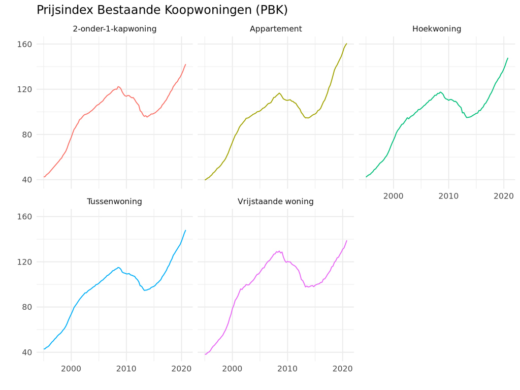

```r
prijsindex_type_woning %>%
  filter(type_woning != "Totaal woningen") %>%
  filter(type_woning != "EGW") %>%
  ggplot(aes(x=date, y=prijsindex_type_woning)) +
  geom_line(aes(color = type_woning)) +
  facet_wrap(~ type_woning) +
  labs(
    title = "Prijsindex Bestaande Koopwoningen (PBK)",
    y = "",
    x = '',
    color = 'Type woning'
    ) +
  theme(legend.position = "none")
```

### 5.1.1 Vraag naar woningen

Bij de factoren die de vraag naar woningen bepalen kijken we naar de ontwikkeling van het aantal huishoudens en de samenstelling van de huishoudens. Nederlanders worden steeds ouder, en gezinnen worden kleiner. Deze ontwikkeling leidt mogelijk tot een verschuiving in de vraag - van eengezinswoningen naar kleinere woningen.

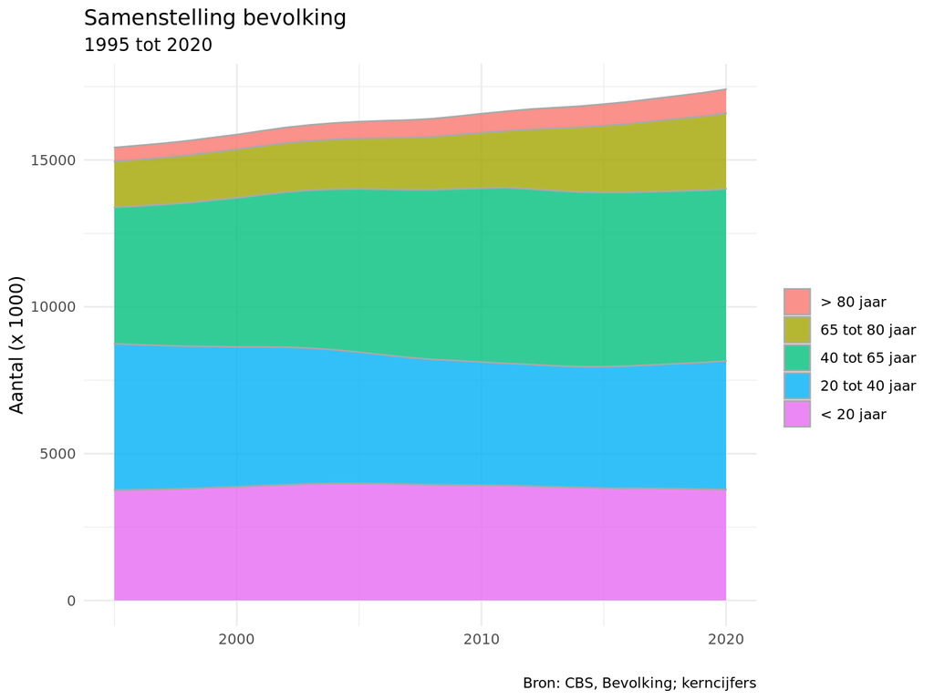

```r
start_date <- as.Date("1995-01-01")

bevolking %>%
  select (date, kl_20_jaar, v20_40_jaar, v40_65_jaar, v65_80_jaar, gd_80_jaar) %>%
  filter (date >= start_date) %>%
  melt (id = c('date')) %>%
  mutate ( variable = factor(variable),
           variable = factor(variable, levels = rev(levels(variable)),
                             labels = c("> 80 jaar",
                                        "65 tot 80 jaar",
                                        "40 tot 65 jaar",
                                        "20 tot 40 jaar",
                                        "< 20 jaar")
                             )) %>%
  mutate (value = value / 1000) %>%
  ggplot ( aes( x = date, y = value, fill = variable) ) +
  geom_area(color = "darkgrey", stat = "identity", alpha = 0.8) +
  labs(
    title = "Samenstelling bevolking",
    subtitle = paste(year(start_date), "tot",year(max(bevolking$date))),
    y = "Aantal (x 1000)",
    x = '',
    caption = "Bron: CBS, Bevolking; kerncijfers",
    fill = ''
    )
```

De groei van de Nederlandse bevolking wordt in de laatste jaren steeds meer bepaald door migratie. Het geboorteoverschot (aantal nieuw geborenen -/- aantal sterfgevallen is nog nooit zo laag geweest). Mogelijk leidt dit tot een verschuiving in de vraag naar meer woningen in de steden. Dit zou verder onderzocht moeten worden.

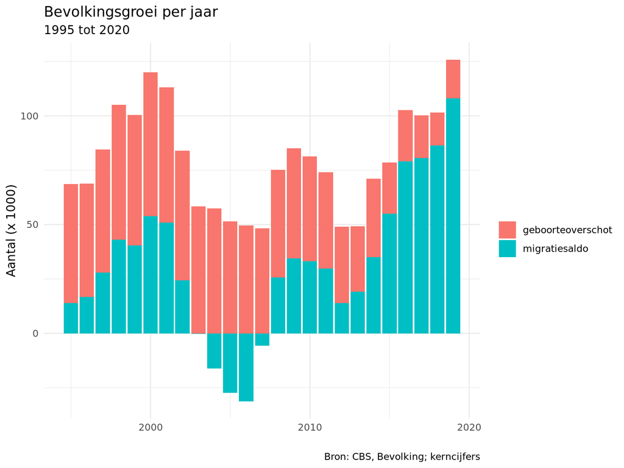

```r
start_date <- as.Date("1995-01-01")

bevolking %>%
  select (date, geboorteoverschot, migratiesaldo) %>%
  filter (date >= start_date) %>%
  melt (id = c('date')) %>%
  mutate (value = value / 1000) %>%
  drop_na %>%
  ggplot(aes (x = date, y=value, fill = variable)) +
  geom_bar(stat="identity") +
  labs(
    title = "Bevolkingsgroei per jaar",
    subtitle = paste(year(start_date), "tot",year(max(bevolking$date))),
    y = "Aantal (x 1000)",
    x = '',
    fill = '',
    caption = "Bron: CBS, Bevolking; kerncijfers"
    )
```

Het CBS maakt regelmatig een prognose van de verwachte groei. Hier zien we dat deze trend zich de aankomende jaren voortzet. De groei komt voornamelijk door de groei van het aantal eenpersoonshuishoudens. De laatste prognoses zijn overigens van 2019. In de prognose zien we een afvlakking van de groei van het aantal huishoudens rond 2040.

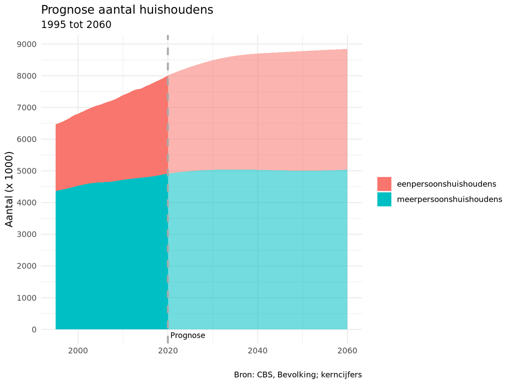

```r
start_date <- as.Date("1995-01-01")

aantal_hh <-
  bevolking %>%
  filter( date >= start_date) %>%
  select (date,
            eenpersoonshuishoudens,
            meerpersoonshuishoudens) %>%
  melt(id = c('date')) %>%
  set_names ('date','type_huishouden', 'aantal')


prognose_hh <-
  prognose_huishoudens_2019 %>%
  select (date,
            eenpersoonshuishoudens,
            meerpersoonshuishoudens) %>%
  melt(id = c('date')) %>%
  set_names ('date','type_huishouden', 'prognose') %>%
  mutate(prognose = prognose / 1000)

aantal_hh %>%
  ggplot(aes (x = date, y=value, fill = variable)) +
  geom_area(aes(y=aantal,
                 fill= type_huishouden
                 )) +
  geom_area(data = prognose_hh,
            aes(y=prognose,
                fill= type_huishouden,
                alpha = 0.1
                 )) +
  geom_vline(xintercept=max(aantal_hh$date), color="darkgrey", size=1, linetype = 'dashed') +
  labs(
    title = "Prognose aantal huishoudens",
    subtitle = paste(year(start_date), "tot",year(max(prognose_hh$date))),
    y = "Aantal (x 1000)",
    x = '',
    caption = "Bron: CBS, Bevolking; kerncijfers"
  ) +
  theme(legend.title = element_blank()) +
  guides(alpha = FALSE) +
  annotate("text", x = max(aantal_hh$date), y = 0,
           label = c(" Prognose") , color="black", hjust = 0, vjust = 1.5,
           size=3) +
  scale_y_continuous(breaks = seq(0, 10000, by = 1000))
```

### 5.1.2 Aanbod van woningen

Wanneer we een wat langere termijn trend kijken naar het aantal gerealiseerde nieuwbouwhuizen zien we dat het aantal nieuwbouwhuizen eigenlijk nu niet bijzonder hoog is. Ondanks dat er meer dan 70.000 huizen bijgebouwd wordt per jaar is dat vergeleken met de totale woningvoorraad eigenlijk niet bijzonder veel. Wel opvallend is dat de laatste jaren er meer overige toevoegingen en overige onttrekkingen geregistreerd worden. Mogelijk geeft dit aan dat de ruimte voor nieuwbouw schaarser wordt waardoor creatiever wordt omgegaan met de beschikbare ruimte.

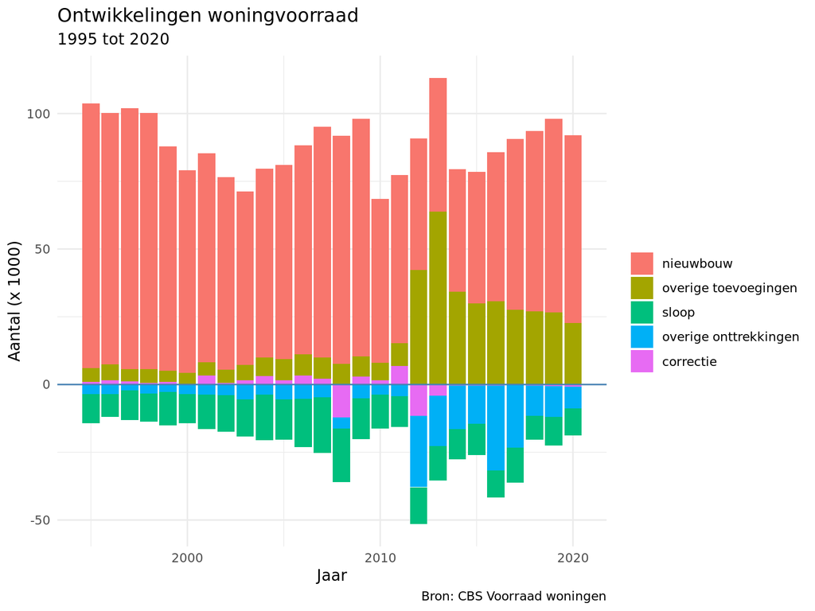

```r
start_date <- as.Date("1995-01-01")

voorraad_woningen %>%
  select(date,
         nieuwbouw,
         overige_toevoegingen,
         sloop,
         Overige_onttrekking,
         correctie
         ) %>%
  mutate (sloop = - sloop ) %>%
  mutate (Overige_onttrekking = - Overige_onttrekking) %>%
  mutate (correctie = - correctie) %>%
  filter( date >= start_date) %>%
  melt (id = c('date')) %>%
  mutate (value = value / 1000) %>%
  mutate (variable = factor(variable, labels = c('nieuwbouw',
                                                 'overige toevoegingen',
                                                 'sloop',
                                                 'overige onttrekkingen',
                                                 'correctie' ))) %>%
  ggplot(aes(x=date, y = value, fill = variable )) +
  geom_bar(stat="identity") +
  geom_hline(yintercept  = 0, color = "steelblue") +
  labs ( title = "Ontwikkelingen woningvoorraad",
         subtitle = paste(year(start_date), "tot",year(max(voorraad_woningen$date))),
         y = "Aantal (x 1000)",
         x = "Jaar",
         caption = "Bron: CBS Voorraad woningen") +
  guides(fill = guide_legend(title = ''))
```

### 5.1.3 Samenhang Vraag en aanbod

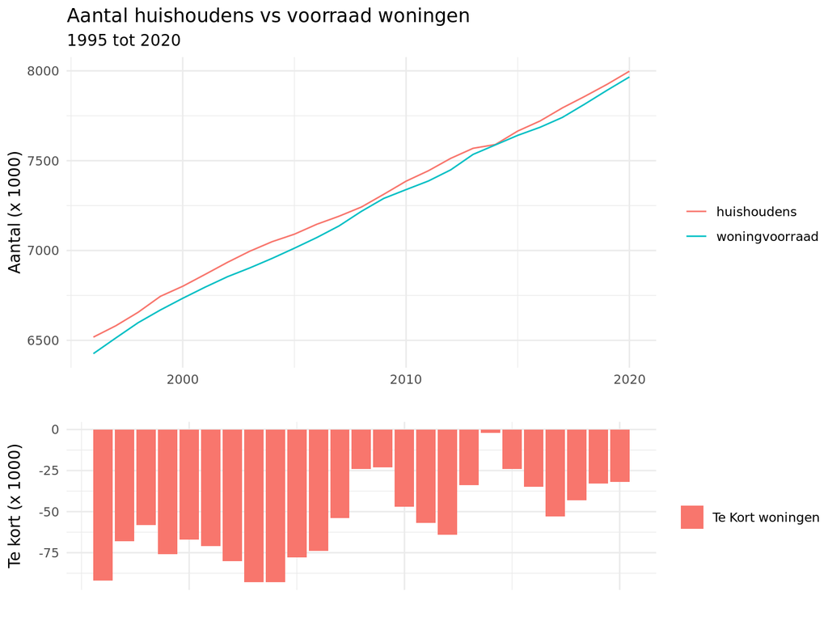

```r
start_date <-as.Date("1995-01-01")

#Aantal huishoudens: NLHSTOTP Thomson Reuters
df <-
  aantal_huishoudens_per_jaar %>%
  full_join(voorraad_woningen, by = c("date" = "date")) %>%
  select (date,
          aantal_huishoudens,
          voorraad) %>%
  set_names('date',
            'huishoudens',
            'woningvoorraad' ) %>%
  mutate(te_kort = (woningvoorraad - huishoudens)) %>%
  filter(date > start_date) %>%
  melt(id = c('date'))

# Line plot
lp<-
  df %>%
  filter (variable != 'te_kort') %>%
  ggplot(aes (x = date)) +
  geom_line(aes(y=value, color = variable)) +
  labs(
    title = "Aantal huishoudens vs voorraad woningen",
    subtitle = paste(year(start_date), "tot",year(max(df$date))),
    y = "Aantal (x 1000)",
    x = '',
    color = ''
    )

# Bar plot
bp <-
  df %>%
  filter (variable == 'te_kort') %>%
  ggplot(aes (x = date)) +
  geom_bar(stat = "identity" ,
           aes(y = value, fill = factor(variable, labels = c("Te Kort woningen")))) +
  labs ( y = "Te kort (x 1000)",
         x = "",
         fill = "") +
  theme( axis.text.x = element_blank(),
         axis.ticks = element_blank())

# Plot line and bar plot together
cowplot::plot_grid(lp, bp, ncol=1, rel_heights = c(2, 1), align = 'v')
```

In bovenstaande grafiek zien we dat het aantal woningen al decennialang gelijke tred houdt met het aantal woningen. Er is daarbij telkens wel een tekort zichtbaar. Dit is veel kleiner dan het door het CBS gerapporteerde tekort van 331.000 woningen [CBS2020b]. In deze studie is er geen verklaring gevonden voor dit verschil. In de verdere analyse wordt uitgegaan van de tekorten zoals hier berekend. Dit is het verschil tussen het aantal huishoudens en de voorraad woningen.

### 5.1.4 Indicatoren Huizenprijzen

Vanwege de (structurele) te korten op de woningmarkt lijken huizenprijzen in belangrijke mate beïnvloed te worden door de financieringsmogelijkheden van de kopers. De rente is historisch laag, de inkomens zijn gestegen en het eigen vermogen is gegroeid. Dit geeft ruimte voor hogere marktprijzen. De fiscale behandeling en regelgeving speelt hier een belangrijke rol, zowel ruimte scheppend - verruimen van de leenmogelijkheden van tweeverdieners, als beperkend - beperking aftrekbaarheid tot 100% financiering.

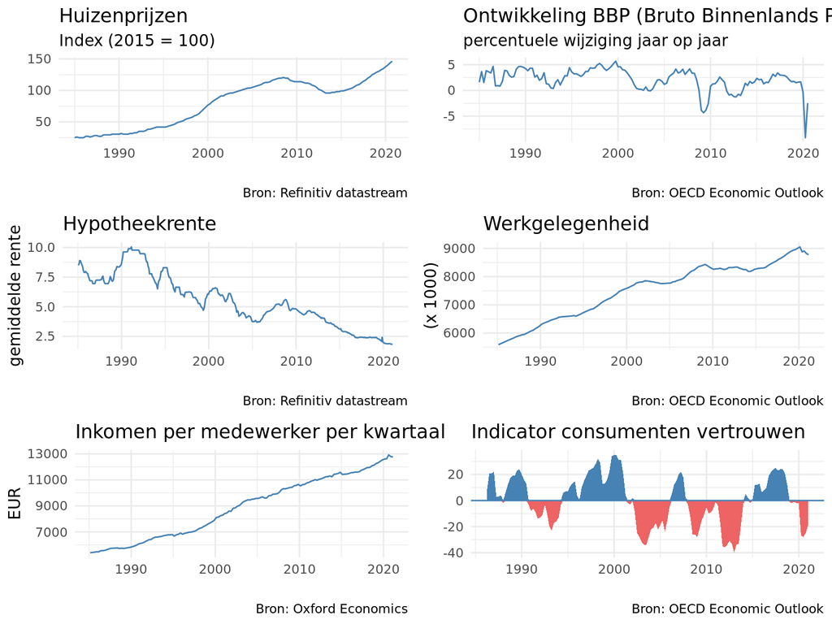

```r
start_date = min(prijsindex_woningen_lt$date)

# House price index existing homes
lp_price <-
  prijsindex_woningen_lt %>%
  ggplot(aes(x = date)) +
  geom_line(aes( y = huisprijsindex), color = 'steelblue') +
  labs(
      title = "Huizenprijzen",
      subtitle = "Index (2015 = 100)",
      y = "",
      x = "",
      caption = "Bron: Refinitiv datastream"
  )

# GDP
lp_gdp <-
  gdp_lt %>%
    filter(date >= start_date) %>%
    ggplot( aes(x=date, y=gdp)) +
      geom_line(color = 'steelblue') +
      labs(
        title = "Ontwikkeling BBP (Bruto Binnenlands Product)",
        subtitle = "percentuele wijziging jaar op jaar",
        y = "",
        x = '',
        caption = "Bron: OECD Economic Outlook"
        )

# Interest rates
lp_interest <-
  hypotheek_rente %>%
  filter(period >= start_date) %>%
  ggplot( aes(x=period, y=hypotheek_rente)) +
  geom_line(color = 'steelblue')  +
  labs(
    title = "Hypotheekrente",
    y = "gemiddelde rente",
    x = '',
    caption = "Bron: Refinitiv datastream"
    )

# Employment
lp_employment <-
  werkgelegenheid_lt %>%
  filter(date >= start_date) %>%
  ggplot(aes(x = period, y = werkgelegenheid)) +
  geom_line(color = 'steelblue') +
  labs(
    title = "Werkgelegenheid",
    y = "(x 1000)",
    x = '',
    caption = "Bron: OECD Economic Outlook"
  )

# Income
lp_income <-
  inkomen_lt %>%
  filter(date >= start_date) %>%
  ggplot(aes(x = period, y = inkomen)) +
  geom_line(color = 'steelblue') +
  labs(
    title = "Inkomen per medewerker per kwartaal",
    y = "EUR",
    x = '',
    caption = "Bron: Oxford Economics"
  )

# Consumer Confidence
lp_consumer_conf <-
  consumenten_vertrouwen_lt_q %>%
  filter(date >= start_date) %>%
  mutate(pos = ifelse(consumer_conf >= 0,consumer_conf, 0)) %>%
  mutate(neg = ifelse(consumer_conf < 0,consumer_conf, 0)) %>%
  ggplot(aes(x = date)) +
  geom_area(aes(y = pos), fill = 'steelblue')  +
  geom_area(aes(y = neg), fill = 'indianred2')  +
  geom_hline (yintercept = 0, color = 'steelblue') +
  labs(
    title = "Indicator consumenten vertrouwen",
    y = "",
    x = "",
    caption = "Bron: OECD Economic Outlook"
  )

cowplot::plot_grid(lp_price, lp_gdp, lp_interest, lp_employment, lp_income,lp_consumer_conf, ncol = 2)
```

Over de vermogens van huishoudens en de wijzigingen in regelgeving zijn er helaas geen langere termijn gegevens gevonden. Een veronderstelling van dit onderzoek was dat door het gewijzigde beleid en de stijgende huizenprijzen het vermogen van huishoudens zou stijgen (Vogt, Kalara, & Voogt, 2018). Daardoor heeft men ook weer meer vermogen beschikbaar voor de aanschaf van woningen wat een prijsopdrijvend effect kan hebben. Dit is door gebrek en data helaas niet verder te verifiëren.

### 5.1.5 Huizenprijzen voorspellen

In deze studie is gekeken naar een aantal modellen om een voorspelling te kunnen doen over de ontwikkeling van de huizenprijzen. Voor alle modellen is de data tot en met 2015 genomen als training data. Het model geeft daarmee een voorspelling over de jaren 2016 tot 2020. Op deze wijze kunnen we een vergelijking maken tussen de modellen. Om de voorspellende factoren vergelijkbaar te maken is gekeken naar de jaar-op-jaar wijzigingen in de factoren. Voor Bruto Binnenlands Product is dit zo aangeleverd. De overige indicatoren zijn omgerekend naar percentuele wijziging jaar-op-jaar.

#### 5.1.5.1 Correlatie van huisprijzen

We vinden de volgende correlaties tussen inkomen, werkgelegenheid, BBP en huizenprijzen.

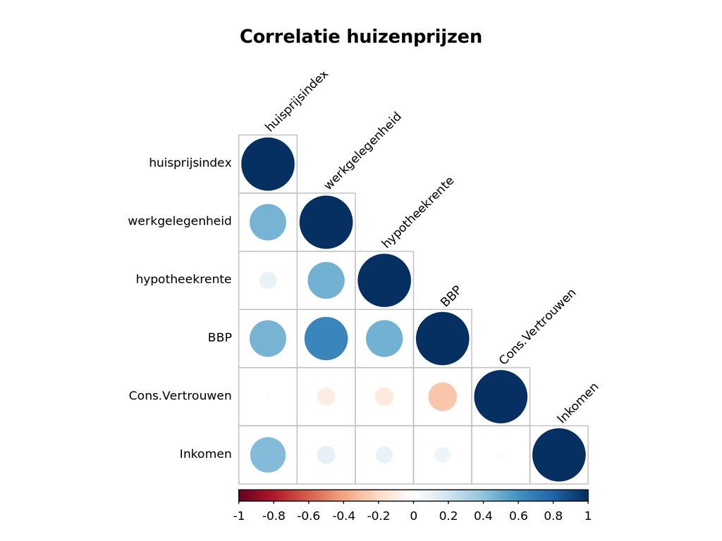

```r
# plot correlations
corMatrix <- round(cor(df_rm_huizenprijzen %>%
                         select(huisprijsindex_yoy,
                                werkgelegenheid_yoy,
                                hypotheek_rente_yoy,
                                gdp,
                                consumer_conf_yoy,
                                inkomen_yoy)),5)

corCols <- c("huisprijsindex",
             "werkgelegenheid",
             "hypotheekrente",
             "BBP",
             "Cons.Vertrouwen",
             "Inkomen")

colnames(corMatrix) <- corCols
rownames(corMatrix) <- corCols

corrplot(corMatrix,
            title = "Correlatie huizenprijzen",
            type = "lower",
            tl.cex = 0.8,
            tl.col = "black",
            tl.srt = 45,
         mar=c(0, 0, 4, 0) # correction titles http://stackoverflow.com/a/14754408/54964
         )
```

#### 5.1.5.2 Regressie Huizenprijzen

Regressie model zou rekening moeten houden met het tijdskarakter van dit soort reeksen. We vinden hiervan voorbeelden in de econometrie (Hanck, Martin, Alexander, & Schmelzer, 2020). In deze studie is uitgegaan van een eenvoudig model om deze tijdseffecten mee te nemen in de regressieanalyse. Voor het lineair model met tijdsreekscorrectie worden van alle voorspellende factoren vier kwartalen historische waarde meegenomen als mogelijke voorspelling van de huizenprijzen.

```r
#' lagdata
#'
#' Add lags to timeseries data. We assume the time serie is represented as a dataframe with column 'date'
#' This routine will then go on and add 4 lags to all variables
#'
#' @param df
#'
#' @return df
#' @export
#'
#' @examples
lagdata <- function(df){


  for (name in colnames(df)) {
    if (name != 'date') {
        for (i in 1:4) {
          variable_name = paste0(name,i)
          # add lagged data to the dataframe
          df[[variable_name]]= lag(df[[name]],i)
        }
    }
  }
return (df)
}


# add lagging data to the dataframe...
# the price we need to pay is loose one year of data for the predictions...
df_rm_huizenprijzen <-
  df_rm_huizenprijzen %>%
  select(date,
         huisprijsindex_yoy,
         werkgelegenheid_yoy,
         hypotheek_rente_yoy,
         gdp,
         consumer_conf_yoy,
         inkomen_yoy) %>%
  lagdata() %>%
  drop_na()
```

```r
# Split data set in Training and Testing set.
# Ideally we should use time slices and repeat the training for each period
# This type of analyses is beyond the scope of this research
df_train <- df_rm_huizenprijzen %>%
  filter(date <= (max(df_rm_huizenprijzen$date) - years(5)))
df_test <- df_rm_huizenprijzen %>%
  filter(date > (max(df_rm_huizenprijzen$date) - years(5)))
```

```r
# lineair regression models

lm_inkomen         = lm(huisprijsindex_yoy~inkomen_yoy, data = df_train)
lm_time            = lm(huisprijsindex_yoy ~ date, data = df_train)
lm_werkgelegenheid = lm(huisprijsindex_yoy~werkgelegenheid_yoy, data = df_train)
lm_gdp             = lm(huisprijsindex_yoy~gdp, data = df_train)
lm_rente           = lm(huisprijsindex_yoy~hypotheek_rente_yoy, data = df_train)
lm_confidence      = lm(huisprijsindex_yoy~consumer_conf_yoy, data = df_train)

tab_model(lm_inkomen,lm_werkgelegenheid,lm_rente,
          title = 'Vergelijking linaire regressie modellen')
```

Vergelijking linaire regressie modellen

|  | huisprijsindex yoy |  |  | huisprijsindex yoy |  |  | huisprijsindex yoy |  |  |
| --- | --- | --- | --- | --- | --- | --- | --- | --- | --- |
| Predictors | Estimates | CI | p | Estimates | CI | p | Estimates | CI | p |
| (Intercept) | 0.64 | -1.26 – 2.55 | 0.505 | 1.98 | 0.56 – 3.40 | **0.007** | 5.08 | 3.88 – 6.29 | **<0.001** |
| inkomen_yoy | 1.69 | 1.07 – 2.32 | **<0.001** |  |  |  |  |  |  |
| werkgelegenheid_yoy |  |  |  | 2.40 | 1.61 – 3.19 | **<0.001** |  |  |  |
| hypotheek_rente_yoy |  |  |  |  |  |  | 0.06 | -0.03 – 0.16 | 0.211 |
| Observations | 111 |  |  | 111 |  |  | 111 |  |  |
| R<sup>2</sup> / R<sup>2</sup> adjusted | 0.209 / 0.202 |  |  | 0.250 / 0.244 |  |  | 0.014 / 0.005 |  |  |

```r
tab_model(lm_gdp,lm_time, lm_confidence,
          title = 'Vergelijking linaire regressie modellen')
```

Vergelijking linaire regressie modellen

|  | huisprijsindex yoy |  |  | huisprijsindex yoy |  |  | huisprijsindex yoy |  |  |
| --- | --- | --- | --- | --- | --- | --- | --- | --- | --- |
| Predictors | Estimates | CI | p | Estimates | CI | p | Estimates | CI | p |
| (Intercept) | 0.69 | -0.72 – 2.10 | 0.336 | 18.20 | 14.03 – 22.36 | **<0.001** | 4.95 | 3.75 – 6.14 | **<0.001** |
| gdp | 1.92 | 1.45 – 2.39 | **<0.001** |  |  |  |  |  |  |
| date |  |  |  | -0.00 | -0.00 – -0.00 | **<0.001** |  |  |  |
| consumer_conf_yoy |  |  |  |  |  |  | -2.73 | -25.71 – 20.25 | 0.814 |
| Observations | 111 |  |  | 111 |  |  | 111 |  |  |
| R<sup>2</sup> / R<sup>2</sup> adjusted | 0.372 / 0.367 |  |  | 0.279 / 0.273 |  |  | 0.001 / -0.009 |  |  |

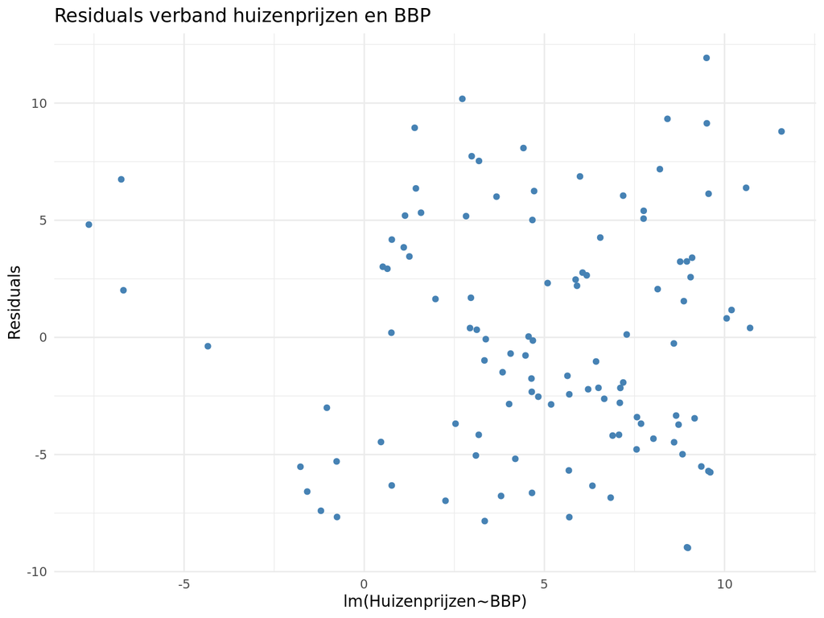

```r
# GDP is best fit for lineair regression
df_rm_lm <- augment(lm_gdp)
ggplot(df_rm_lm, aes(x = .fitted, y = .resid)) +
  geom_point(color = 'steelblue') +
  labs (
      title = 'Residuals verband huizenprijzen en BBP',
      x = 'lm(Huizenprijzen~BBP)',
      y = 'Residuals'
    )
```

```r
# simple multiple regression model including all variables at T0
lm_multi = lm(huisprijsindex_yoy~date+
                werkgelegenheid_yoy+
                hypotheek_rente_yoy+
                gdp+
                consumer_conf_yoy+
                inkomen_yoy, data = df_rm_huizenprijzen )

tab_model(lm_multi,
          title = 'Multple regressie model')
```

Multple regressie model

|  | huisprijsindex yoy |  |  |
| --- | --- | --- | --- |
| Predictors | Estimates | CI | p |
| (Intercept) | -1.53 | -5.62 – 2.57 | 0.462 |
| date | -0.00 | -0.00 – 0.00 | 0.549 |
| werkgelegenheid_yoy | 1.29 | 0.48 – 2.11 | **0.002** |
| hypotheek_rente_yoy | -0.12 | -0.20 – -0.05 | **0.001** |
| gdp | 1.04 | 0.52 – 1.55 | **<0.001** |
| consumer_conf_yoy | 12.45 | -1.93 – 26.82 | 0.089 |
| inkomen_yoy | 1.42 | 0.94 – 1.90 | **<0.001** |
| Observations | 131 |  |  |
| R<sup>2</sup> / R<sup>2</sup> adjusted | 0.476 / 0.451 |  |  |

Met behulp van de caret module (Kuhn, 2020) kan een optimalisatie worden uitgevoerd om het best passende model te selecteren. We zien hier dat het model gebruik maakt van alle beschikbare data, en dan tot nog een betere fit komt op de aangeboden training data.

```r
# The carot model can train the best multiple regression model optimizing RMSE (Root Mean Squared Error).
lm_compute <- train(
  huisprijsindex_yoy ~ .,
  data = df_train,
  method = "lm",
  metric = "RMSE",
  trControl = trainControl(method = "cv", number = 10),
  preProcess = c("zv", "center", "scale")
  )

tab_model(lm_compute$finalModel,
          title = "Time Series Lineair Model"
          )
```

Time Series Lineair Model

|  | outcome |  |  |
| --- | --- | --- | --- |
| Predictors | Estimates | CI | p |
| (Intercept) | 4.94 | 4.66 – 5.21 | **<0.001** |
| date | 0.00 | -0.40 – 0.40 | 0.986 |
| werkgelegenheid_yoy | -0.53 | -2.13 – 1.08 | 0.516 |
| hypotheek_rente_yoy | -0.14 | -0.92 – 0.64 | 0.721 |
| gdp | 0.57 | -0.34 – 1.47 | 0.217 |
| consumer_conf_yoy | 0.19 | -0.11 – 0.49 | 0.202 |
| inkomen_yoy | 0.30 | -0.36 – 0.96 | 0.371 |
| huisprijsindex_yoy1 | 5.14 | 3.81 – 6.47 | **<0.001** |
| huisprijsindex_yoy2 | 0.02 | -1.68 – 1.71 | 0.986 |
| huisprijsindex_yoy3 | 0.84 | -0.88 – 2.57 | 0.333 |
| huisprijsindex_yoy4 | -1.35 | -2.50 – -0.20 | **0.022** |
| werkgelegenheid_yoy1 | 0.10 | -2.35 – 2.55 | 0.935 |
| werkgelegenheid_yoy2 | -0.82 | -3.38 – 1.73 | 0.522 |
| werkgelegenheid_yoy3 | 0.13 | -2.31 – 2.57 | 0.917 |
| werkgelegenheid_yoy4 | 1.22 | -0.22 – 2.65 | 0.095 |
| hypotheek_rente_yoy1 | -1.04 | -2.29 – 0.20 | 0.100 |
| hypotheek_rente_yoy2 | 0.09 | -1.23 – 1.41 | 0.888 |
| hypotheek_rente_yoy3 | -0.09 | -1.31 – 1.13 | 0.885 |
| hypotheek_rente_yoy4 | 0.14 | -0.66 – 0.94 | 0.730 |
| gdp1 | 1.44 | 0.20 – 2.69 | **0.024** |
| gdp2 | 0.01 | -1.22 – 1.23 | 0.991 |
| gdp3 | -0.53 | -1.73 – 0.66 | 0.376 |
| gdp4 | 0.65 | -0.31 – 1.60 | 0.181 |
| consumer_conf_yoy1 | 0.07 | -0.23 – 0.37 | 0.626 |
| consumer_conf_yoy2 | -0.09 | -0.39 – 0.21 | 0.552 |
| consumer_conf_yoy3 | -0.19 | -0.49 – 0.10 | 0.196 |
| consumer_conf_yoy4 | -0.28 | -0.57 – 0.01 | 0.061 |
| inkomen_yoy1 | -0.61 | -1.41 – 0.18 | 0.130 |
| inkomen_yoy2 | -0.07 | -0.88 – 0.74 | 0.860 |
| inkomen_yoy3 | 0.28 | -0.53 – 1.08 | 0.496 |
| inkomen_yoy4 | 0.45 | -0.26 – 1.15 | 0.210 |
| Observations | 111 |  |  |
| R<sup>2</sup> / R<sup>2</sup> adjusted | 0.962 / 0.948 |  |  |

Tot slot is gekeken of nog een beter passend model verkregen kan worden met MARS (multivariate adaptive regression splines (Friedman, 2007). Deze methode splits de regressie in meerdere ‘splines’. Hierbij is gebruik gemaakt van het R package earth (Trevor Hastie & Thomas Lumley’s leaps wrapper., 2020). Waardoor in theorie een betere fit gevonden moet kunnen worden.

Het MARS model wordt geoptimaliseerd om zo de meest relevante factoren te vinden. Wanneer met dit model geprobeerd wordt om de prijsontwikkeling van de afgelopen 5 jaar te voorspellen geeft dit model een goede fit.

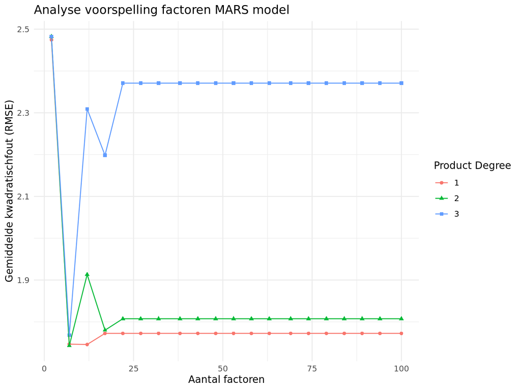

```r
# Simple MARS model

# Tuning the model
# Optimal number of degrees and number of variables to prune is calculated

# create a tuning grid
hyper_grid <- expand.grid(
  degree = 1:3,
  nprune = seq(2, 100, length.out = 20) %>% floor()
  )

# for reproducibiity
set.seed(123)

# cross validated model
tuned_mars <- train(
  x = subset(df_train, select = -huisprijsindex_yoy),
  y = df_train$huisprijsindex_yoy,
  method = "earth",
  metric = "RMSE",
  trControl = trainControl(method = "cv", number = 10),
  tuneGrid = hyper_grid
)

# plot results
# I was not able to change the legend title
ggplot(tuned_mars) +
  labs (
      title = 'Analyse voorspelling factoren MARS model',
      x = 'Aantal factoren',
      y = 'Gemiddelde kwadratischfout (RMSE)'
    )
```

Door middel van de optimalisatie wordt hier het aantal factoren en de mate van interactie tussen de factoren (product degree) geselecteerd.

```r
# fit model
fit <- earth(huisprijsindex_yoy~., df_train,
             degree = tuned_mars$bestTune$degree, nprune = tuned_mars$bestTune$nprune)

# summarize the importance of input variables
kable(tidy(print(evimp(fit))),
      caption = "Belangrijkse indicatoren MARS model huizenprijzen",
      digits = 3
      ) %>% kable_styling()
```

```
##                      nsubsets   gcv    rss
## huisprijsindex_yoy1         6 100.0  100.0
## hypotheek_rente_yoy3        4  14.4   17.6
## gdp4                        4  14.4   17.6
## huisprijsindex_yoy4         3   9.8   13.2
## werkgelegenheid_yoy4        2   9.2   11.3
## hypotheek_rente_yoy1        1   8.3    9.1
```

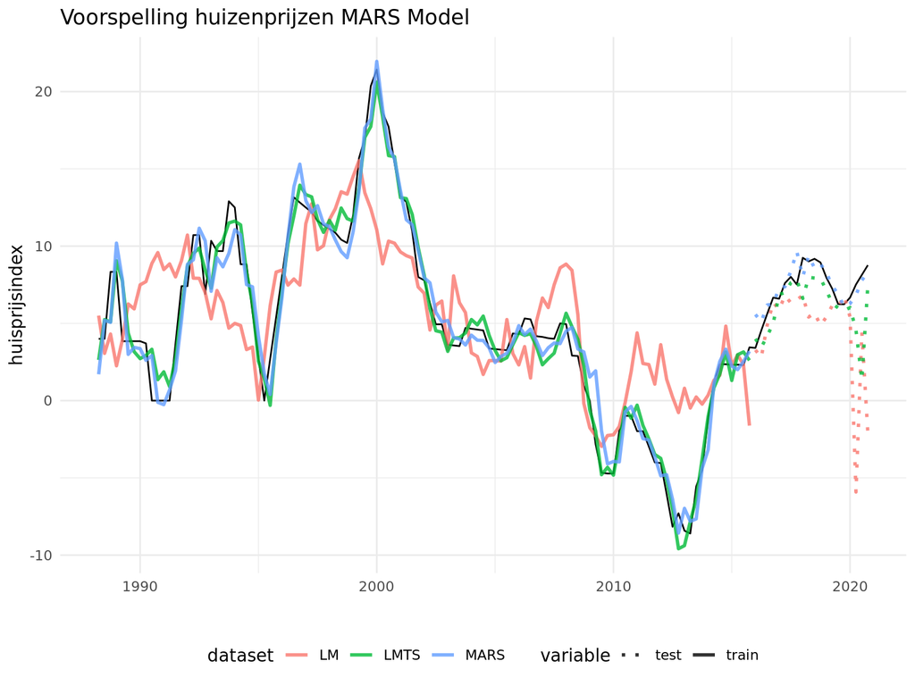

```r
# make predictions for MARS model
train_predictions <- predict(fit, df_train)
test_predictions <- predict(fit, df_test)

# make predictions for our regression model
train_lm_predictions <- predict(lm_multi, df_train)
test_lm_predictions <- predict(lm_multi, df_test)

# make predictions for our ts regression model
train_lmts_predictions <- predict(lm_compute, df_train)
test_lmts_predictions <- predict(lm_compute, df_test)

df_result <-
  tibble (
    date = df_train$date,
    huisprijsindex_yoy = df_train$huisprijsindex_yoy,
    predicted = train_predictions,
    variable = 'train',
    model = 'MARS'
  ) %>%
  union_all(
    tibble(
      date = df_test$date,
      huisprijsindex_yoy = df_test$huisprijsindex_yoy,
      predicted = test_predictions,
      variable = 'test',
      model = 'MARS')) %>%
  union_all(
    tibble(
      date = df_train$date,
      huisprijsindex_yoy = df_train$huisprijsindex_yoy,
      predicted = train_lm_predictions,
      variable = 'train',
      model = 'LM')) %>%
  union_all(
    tibble(
      date = df_test$date,
      huisprijsindex_yoy = df_test$huisprijsindex_yoy,
      predicted = test_lm_predictions,
      variable = 'test',
      model = 'LM')) %>%
  union_all(
    tibble(
      date = df_train$date,
      huisprijsindex_yoy = df_train$huisprijsindex_yoy,
      predicted = train_lmts_predictions,
      variable = 'train',
      model = 'LMTS') %>%
  union_all(
    tibble(
      date = df_test$date,
      huisprijsindex_yoy = df_test$huisprijsindex_yoy,
      predicted = test_lmts_predictions,
      variable = 'test',
      model = 'LMTS'))
  )

df_result %>%
  ggplot(aes(date, huisprijsindex_yoy)) +
  geom_line(size = .5) +
  geom_line(aes(y = predicted, color = model, linetype = variable),
            size = 1, alpha = 0.8) +
  scale_linetype_manual(values=c("dotted","solid"))+
  labs(
    title = "Voorspelling huizenprijzen MARS Model",
    y = "huisprijsindex",
    x = '',
    color = 'dataset'
  ) +
  theme(legend.position="bottom")
```

Het lineair regressiemodel geeft duidelijk een minder goede fit dan het time series model en het MARS model. Het MARS model sluit heel goed aan bij de ontwikkeling van de huizenprijzen over de afgelopen vijf jaar.

### 5.1.6 Regionale verschillen

Er bestaan grote regionale verschillen in huisprijzen. Door het ontbreken van gedetailleerde tijdsreeksen is de ontwikkeling van de regionale verschillen over de tijd is in deze studie niet verder onderzocht.

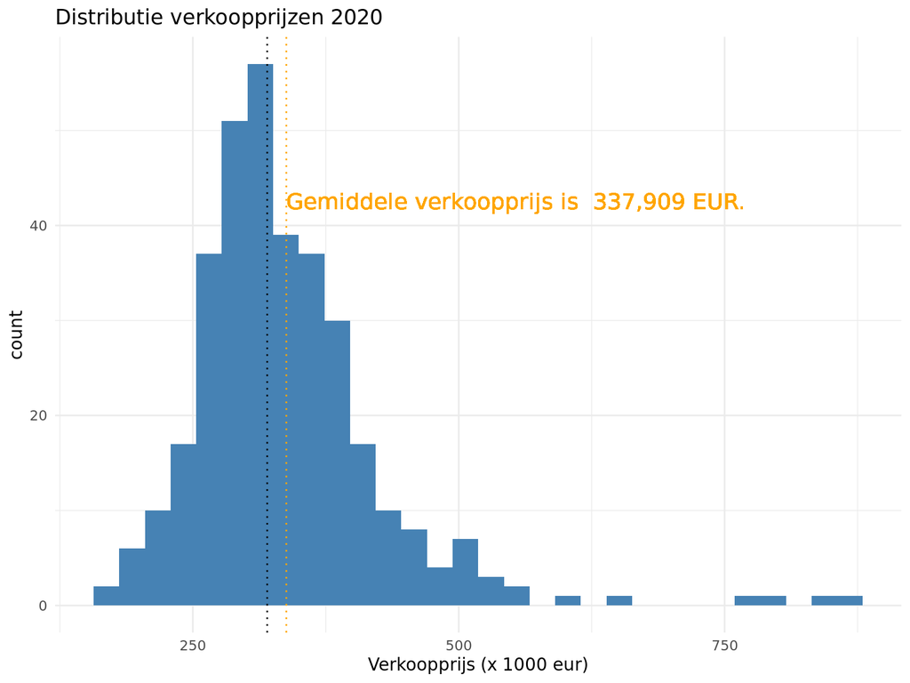

```r
# histogram
verkoopprijs_regio %>%
  filter(date == as.Date('2020-01-01')) %>%
  drop_na(verkoopprijs) %>%
  mutate(verkoopprijs = verkoopprijs / 1000) %>%
  ggplot(aes(x = verkoopprijs, color = verkoopprijs) ) +
  geom_histogram(bins = 30,fill = 'steelblue') +
  geom_vline(aes(xintercept = median(verkoopprijs)), colour="black", linetype = 'dotted') +
  geom_vline(aes(xintercept = mean(verkoopprijs)), colour="orange", linetype = 'dotted') +
  geom_text(aes(label=paste("Gemiddele verkoopprijs is ",
                            format(round(mean(verkoopprijs*1000)), nsmall=0, big.mark=","), "EUR."),y=40,x=mean(verkoopprijs)),
            vjust=-1,hjust = 0, col='orange',size=5) +
  labs(title = "Distributie verkoopprijzen 2020",
        x = "Verkoopprijs (x 1000 eur)") +
  theme(legend.position = "none")
```

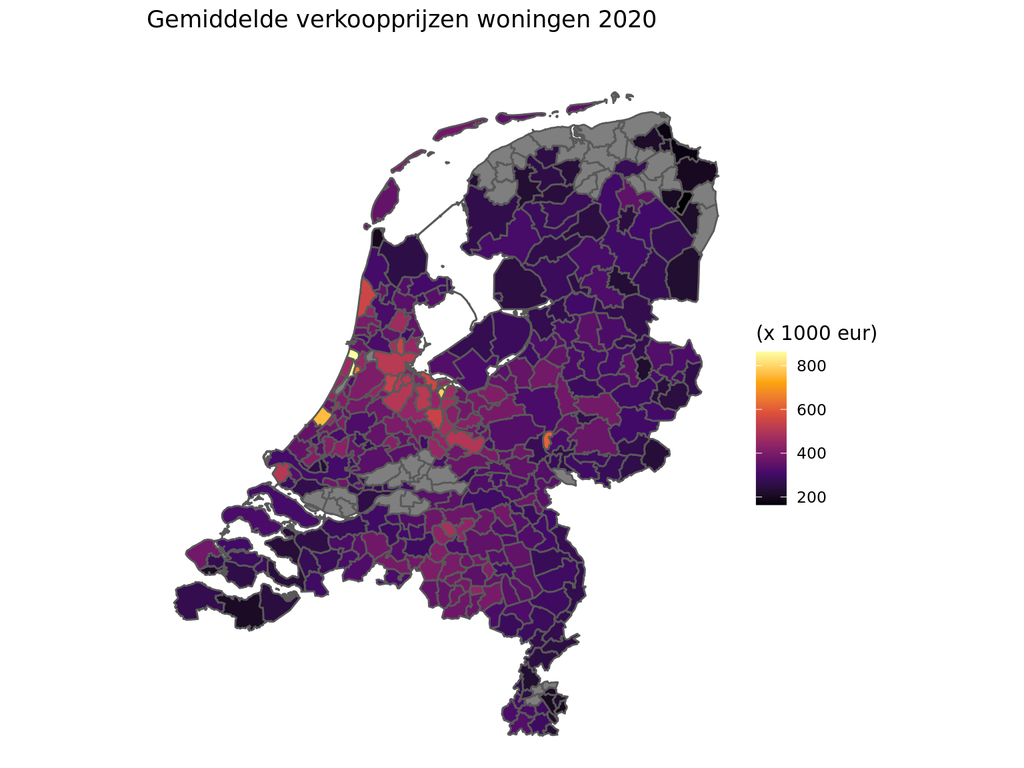

```r
# Create a thematic map
verkoopprijs_regio %>%
  filter(date == as.Date('2020-01-01')
           ) %>%
  mutate(verkoopprijs = verkoopprijs / 1000) %>%
  ggplot() +
  geom_sf(aes(fill = verkoopprijs)) +
  scale_fill_viridis_c(option = "inferno") +
  labs(title = "Gemiddelde verkoopprijzen woningen 2020",
       subtitle = "",
       fill = "(x 1000 eur)") +
  theme_void()
```

## 5.2 Aantal transacties

### 5.2.1 Ontwikkeling aantal transacties

Het aantal transacties heeft in de crisis jaren 2009 - 2012 een duidelijke terugval laten zien. Sindsdien zien we een snelle inhaalbeweging, en nog steeds zien we aanzienlijk hogere transactie volumes dan voorheen.

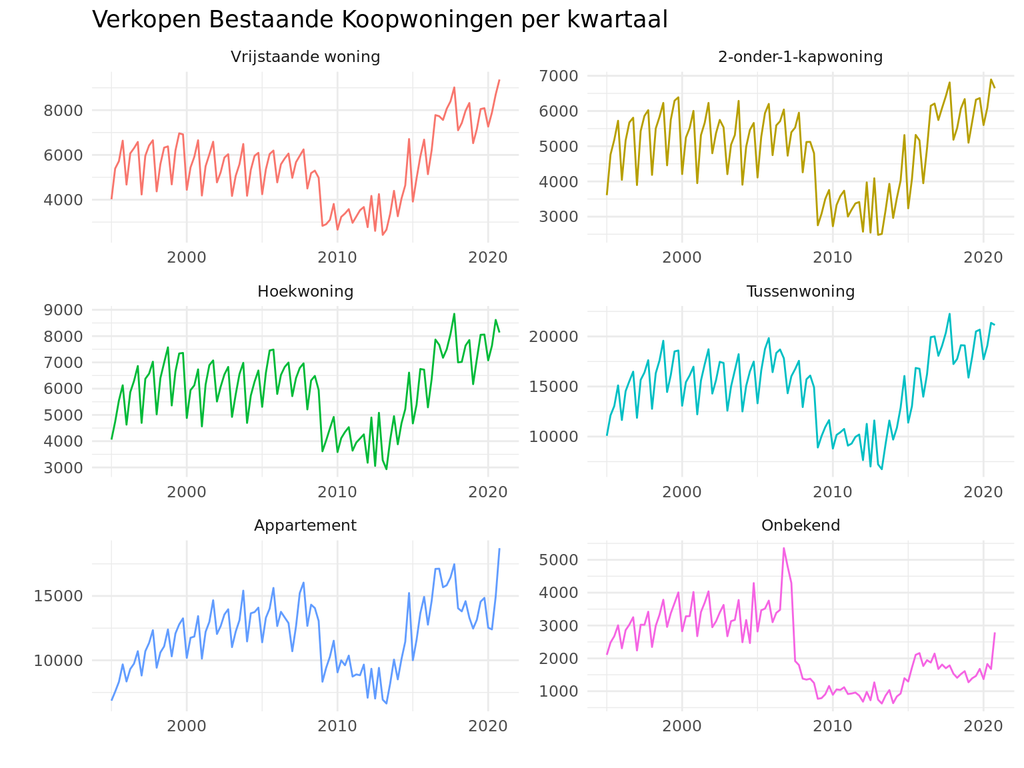

```r
verkochte_woningen_per_type_per_kwartaal %>%
  mutate(subtype = factor(subtype, levels=c('Vrijstaande woning',
                                  '2-onder-1-kapwoning',
                                  'Hoekwoning',
                                  'Tussenwoning',
                                  'Appartement',
                                  'Onbekend'))) %>%
  ggplot(aes(x=date, y=verkochte_bestaande_woningen )) +
  geom_line(aes(color = subtype)) +
  facet_wrap(~ subtype, ncol = 2, scales = "free") +
  labs(
    title = "Verkopen Bestaande Koopwoningen per kwartaal",
    y = "",
    x = '',
    color = 'subtype'
    ) +
  theme(legend.position = "none")
```

Wanneer gekeken wordt naar de transactie volumes valt de piek op in appartementen in het laatste kwartaal van 2020. Dit is te verklaren door de wijziging in de regelgeving voor beleggers. Particuliere beleggers op de woningmarkt moeten vanaf 2021 8% overdrachtsbelasting betalen. Dit heeft gezorgd voor een eenmalige piek in aankopen door deze groep. Tegelijkertijd is er begin 2021 een vrijstelling van overdrachtsbelasting voor jongeren tot 35 jaar. Jongeren hebben daarom veelal de aankoop uitgesteld naar het eerste kwartaal van 2021. Deze effecten van regelgeving zien we terug in de data.

### 5.2.2 Voorspellen van aantal transacties

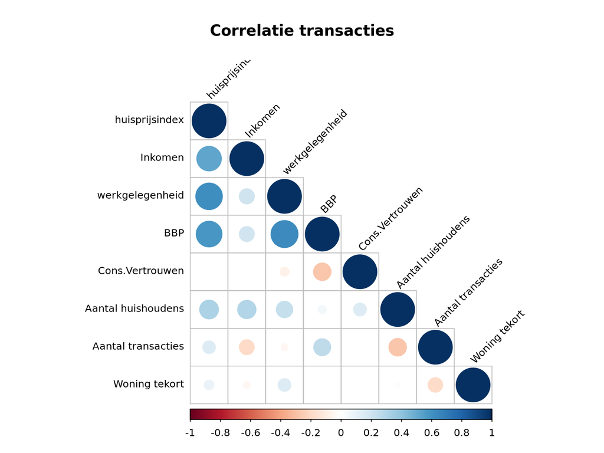

```r
corMatrix <- round(cor(df_rm_transactions %>%
                         select(-date)),5)

corCols <- c("huisprijsindex",
             "Inkomen",
             "werkgelegenheid",
             "BBP",
             "Cons.Vertrouwen",
             "Aantal huishoudens",
             "Aantal transacties",
             "Woning tekort")

colnames(corMatrix) <- corCols
rownames(corMatrix) <- corCols

corrplot(corMatrix,
            title = "Correlatie transacties",
            type = "lower",
            tl.cex = 0.8,
            tl.col = "black",
            tl.srt = 45,
            mar=c(0, 0, 4, 0))
```

Het MARS model geeft op basis van deze gegevens geen goede voorspelling. Mogelijk dat de effecten van de COVID-crisis hier onvoorziene invloeden hebben op de voorspelling.

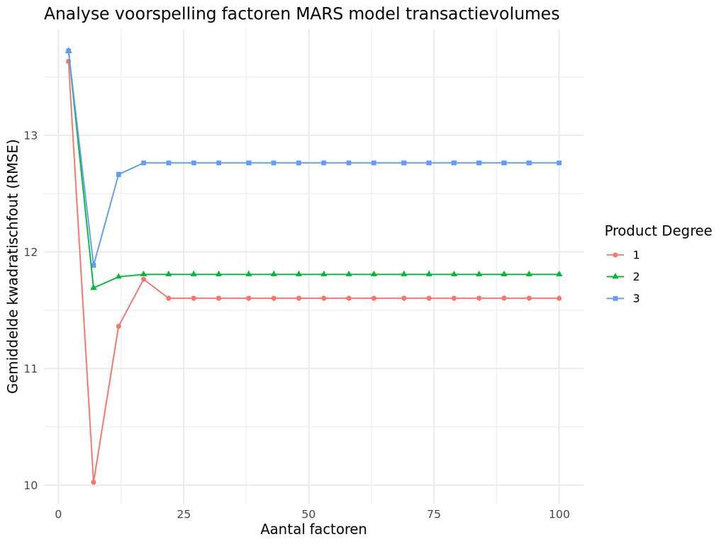

```r
# Add Lineair regression model - for number of households and transactions...

# Add 4 lags of data
df_rm_transactions <-
  df_rm_transactions %>%
  lagdata() %>%
  drop_na()

# Split in Train and Test data set
df_train <- df_rm_transactions %>%
  filter(date <= (max(df_rm_transactions$date) - years(5)))
df_test <- df_rm_transactions %>%
  filter(date > (max(df_rm_transactions$date) - years(5)))


# Tuning the model
# Optimal number of defrees and number of variables to prune is calculated

# create a tuning grid
hyper_grid <- expand.grid(
  degree = 1:3,
  nprune = seq(2, 100, length.out = 20) %>% floor()
)


# for reproducibiity
set.seed(123)

# cross validated model
tuned_mars <- train(
  x = subset(df_train, select = -verkocht_yoy),
  y = df_train$verkocht_yoy,
  method = "earth",
  metric = "RMSE",
  trControl = trainControl(method = "cv", number = 10),
  tuneGrid = hyper_grid
)

# plot results
ggplot(tuned_mars) +
  labs (
      title = 'Analyse voorspelling factoren MARS model transactievolumes',
      x = 'Aantal factoren',
      y = 'Gemiddelde kwadratischfout (RMSE)'
    )
```

```r
# fit model
fit <- earth(verkocht_yoy~., df_train,
             degree = tuned_mars$bestTune$degree, nprune = tuned_mars$bestTune$nprune)
# summarize the fit
# summary(fit)

# summarize the importance of input variables
kable(tidy(print(evimp(fit))),
      caption = "Belangrijkse indicatoren MARS model transacties",
      digits = 3) %>%
      kable_styling()
```

```
##                      nsubsets   gcv    rss
## aantal_hh_yoy               6 100.0  100.0
## gdp                         5  76.0   76.4
## verkocht_yoy1               4  50.1   53.1
## verkocht_yoy3-unused        1  19.6   22.3
```

Belangrijkse indicatoren MARS model transacties

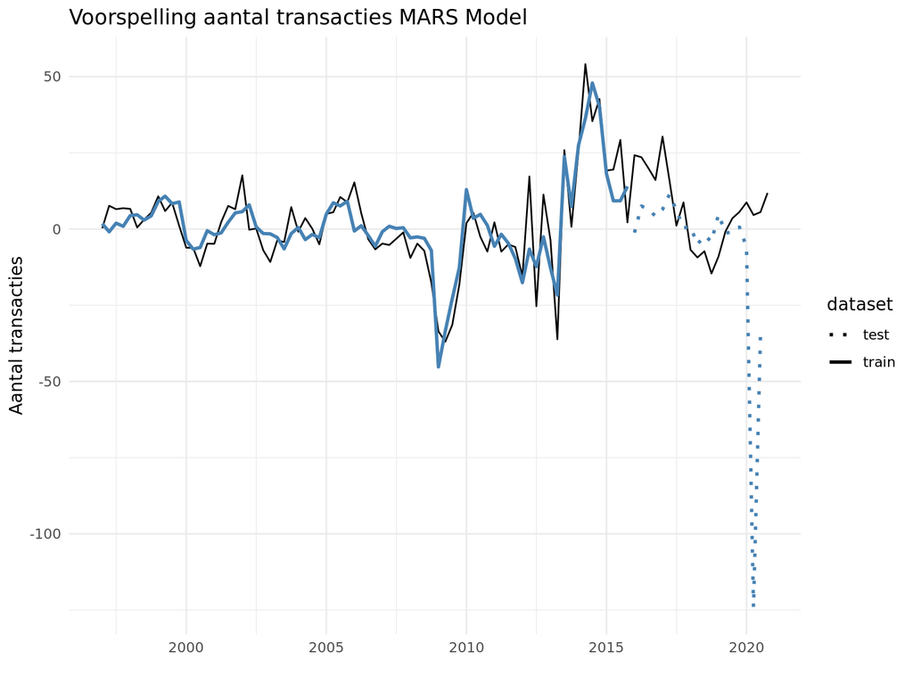

```r
# make predictions
train_predictions <- predict(fit, df_train)
test_predictions <- predict(fit, df_test)

df_result <-
  tibble (
    date = df_train$date,
    verkocht_yoy = df_train$verkocht_yoy,
    predicted = train_predictions,
    variable = 'train'
  ) %>%
  union_all(
    tibble(
      date = df_test$date,
      verkocht_yoy = df_test$verkocht_yoy,
      predicted = test_predictions,
      variable = 'test')
)

df_result %>%
  ggplot(aes(date, verkocht_yoy)) +
  geom_line(size = 0.5) +
  geom_line(aes(y = predicted, linetype = variable, color = 'steelblue'), size = 1) +
  scale_linetype_manual(values=c("dotted","solid")) +
  scale_color_manual(values=c("steelblue")) +
  labs(
    title = "Voorspelling aantal transacties MARS Model",
    y = "Aantal transacties",
    x = '',
    linetype = 'dataset'
  ) + guides(color = FALSE)
```

### 5.2.3 Tijdreeksanalyse transactievolumes

Om de ontwikkeling van de transactievolumes verder te analyseren is een tijdreeksanalyse uitgevoerd op de data (Hyndman & Athanasopoulos, 2018). De ACf (auto correlatie) plot toont dat meer recente data significant is, wat een trend aangeeft in de data. De PACF plot (partial auto-correlation function) toont dat recente data en seizoensinvloeden een goede indicatie geven voor het modeleren van de trend.

De uiteindelijke voorspelling laat het seizoenspatroon zien. Verder wordt door dit model de recente trend doorgetrokken, terwijl eigenlijk verwacht zou mogen worden dat op termijn de volumes op de huizenmarkt terugkeren naar een stabiel niveau.

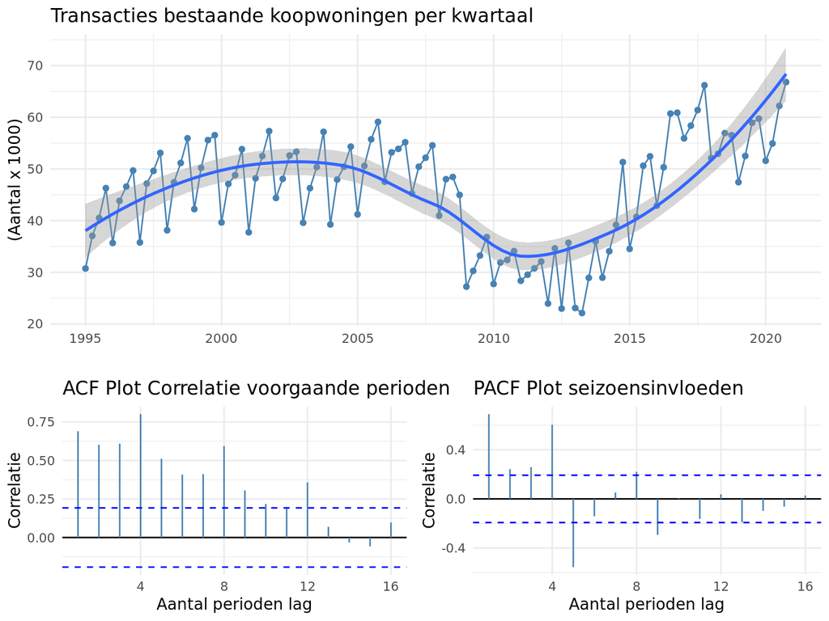

```r
#
# vw <- verkochte_woningen_per_type_per_kwartaal %>%
#   group_by (yearqtr) %>%
#   summarise(totaal = sum(verkochte_bestaande_woningen) / 1000 )


#' calculate_aic
#'
#' Calculate best fit model using AIC
#'
#' @param ts
#'
#' @return dataset with models ordered by AIC
calculate_aic<-function(ts) {

  # https://stackoverflow.com/questions/37998486/sorting-arima-aic-in-r
  # Order is a matrix describing the p, d, q values to be tested
  order.matrix <- matrix(0, nrow = 3, ncol = 4 * 2 * 4)
  aic.vec <- numeric(4 * 2 * 4)
  k <- 1
  for (p in 1:4) for (d in 0:1) for (q in 1:4) {
    order.matrix[, k] <- c(p,d,q)
    aic.vec[k] <- AIC(arima(vwts, order=c(p, d, q), seasonal= c(0,1,1)))
    k <- k+1
    }
  ind <- order(aic.vec, decreasing = FALSE)
  aic.vec <- aic.vec[ind]
  order.matrix <- order.matrix[, ind]
  order.matrix <- t(order.matrix)
  result <- cbind(order.matrix, aic.vec)
  colnames(result) <- c("p", "d", "q", "AIC")

  return (result)
}

# Time series object
vwts <- ts(verkochte_woningen_per_kwartaal["totaal"],
              start = c(1995, 1), frequency = 4)


# Aantal tranascties per kwartaal
v<-vwts %>%
  autoplot(color = 'steelblue') +
  geom_point(color = 'steelblue') +
  geom_smooth() +
  labs(
    title = "Transacties bestaande koopwoningen per kwartaal",
    y = "(Aantal x 1000)",
    x = ''
    )

# ACF plot
# Visualizes how much the most recent value of the series
# is correlated with past values of the series
acf <- ggAcf(vwts, lag.max = 16, color = 'steelblue') +
  labs(
    title = "ACF Plot Correlatie voorgaande perioden",
    y = "Correlatie",
    x = "Aantal perioden lag"
    )

# PACF Plot
# Visualizes whether certain lags are good for modeling or not;
# useful for data with a seasonal pattern
pacf <- ggPacf(vwts, lag.max = 16, color = 'steelblue') +
  labs(
    title = "PACF Plot seizoensinvloeden",
    y = "Correlatie",
    x = "Aantal perioden lag"
    )

# Plot both
cowplot::plot_grid(v, cowplot::plot_grid(acf, pacf), ncol = 1, rel_heights = c(1.5, 1))
```

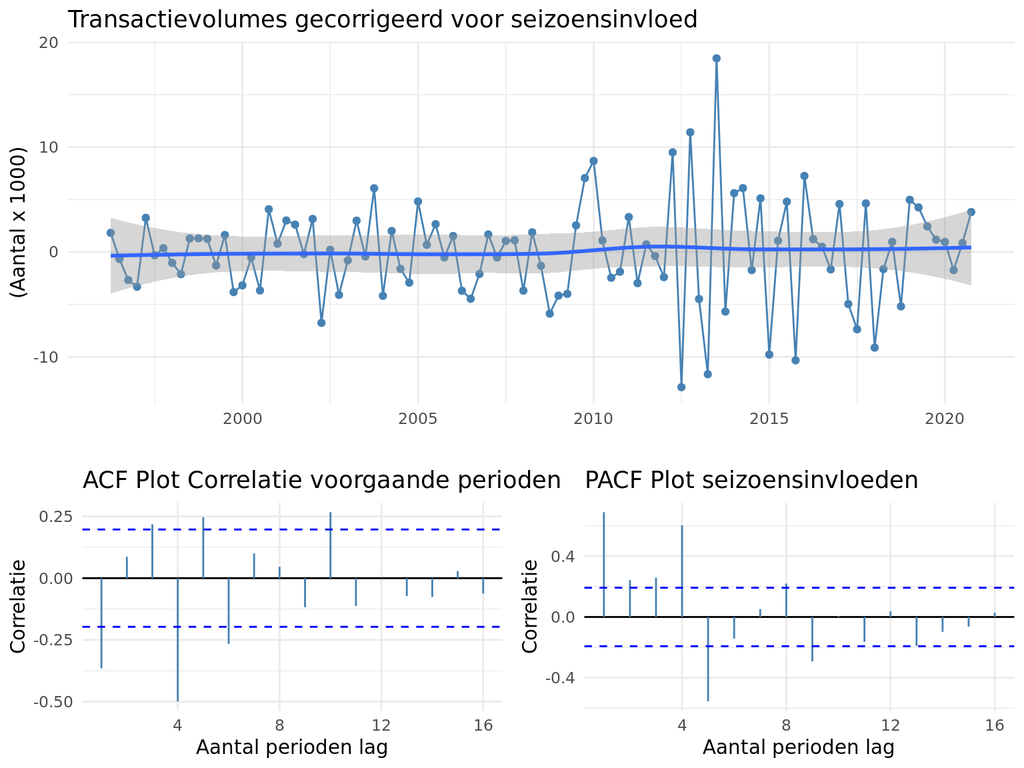

```r
# Take first difference of the plot + seasonal effects
# Lag 1 year - lag 1 quarter - remainder fits model for Arima
vwts_diff <-
  vwts %>%
    diff(lag=4) %>%
    diff()

v1<-vwts_diff %>%
  autoplot(color = 'steelblue') +
  geom_point(color = 'steelblue') +
  geom_smooth() +
  labs(
    title = "Transactievolumes gecorrigeerd voor seizoensinvloed",
    y = "(Aantal x 1000)",
    x = ''
    )

# ACF plot
# Visualizes how much the most recent value of the series
# is correlated with past values of the series
acf1 <- ggAcf(vwts_diff, lag.max = 16, color = 'steelblue') +
  labs(
    title = "ACF Plot Correlatie voorgaande perioden",
    y = "Correlatie",
    x = "Aantal perioden lag"
    )

# PACF Plot
# Visualizes whether certain lags are good for modeling or not;
# useful for data with a seasonal pattern
pacf1 <- ggPacf(vwts, lag.max = 16, color = 'steelblue') +
  labs(
    title = "PACF Plot seizoensinvloeden",
    y = "Correlatie",
    x = "Aantal perioden lag"
    )

# Plot both
cowplot::plot_grid(v1, cowplot::plot_grid(acf1, pacf1), ncol = 1, rel_heights = c(1.5, 1))
```

```r
# Dickey-Fuller Test shows data should be differenced once.
kable(tidy(adf.test(vwts,alternative = "stationary")),
      caption = "ADF Test Transactie volumes",
      digits = 3) %>%
  kable_styling()
```

ADF Test Transactie volumes

| statistic | p.value | parameter | method | alternative |
| --- | --- | --- | --- | --- |
| -1.357 | 0.843 | 4 | Augmented Dickey-Fuller Test | stationary |

```r
kable(tidy(adf.test(diff(vwts),alternative = "stationary")),
      caption = "ADF Test Eerste orde verschil",
      digits = 3
      ) %>%
  kable_styling()
```

ADF Test Eerste orde verschil

| statistic | p.value | parameter | method | alternative |
| --- | --- | --- | --- | --- |
| -3.104 | 0.119 | 4 | Augmented Dickey-Fuller Test | stationary |

```r
kable(tidy(adf.test(diff(diff(vwts),lag=4),alternative = "stationary")),
      caption = "ADF Test Eerste orde verschil and sezoenscorrectie",
      digits = 3
      ) %>%
  kable_styling()
```

ADF Test Eerste orde verschil and sezoenscorrectie

| statistic | p.value | parameter | method | alternative |
| --- | --- | --- | --- | --- |
| -5.812 | 0.01 | 4 | Augmented Dickey-Fuller Test | stationary |

```r
# Calculate Best Akaike Information Critera (AIC) model
kable(head(calculate_aic(vwts)),
      caption = "Selectie ARIMA model op basis van Akaike Information Criteria (AIC)",
      digits = 3) %>%
  kable_styling()
```

Selectie ARIMA model op basis van Akaike Information Criteria (AIC)

| p | d | q | AIC |
| --- | --- | --- | --- |
| 2 | 1 | 2 | 539.154 |
| 2 | 1 | 3 | 539.280 |
| 3 | 1 | 2 | 539.604 |
| 4 | 1 | 2 | 540.849 |
| 2 | 1 | 4 | 541.233 |
| 3 | 1 | 3 | 541.781 |

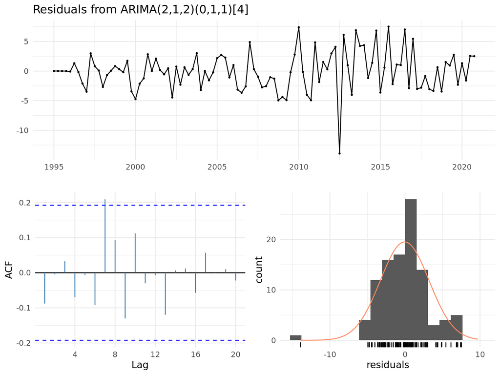

```r
# An Arima 2,1,2 model seems to be the best fit - and we need seasonal correction
# Fit final model - fits beter then auto arima
fit <- Arima(vwts, order=c(2,1,2), seasonal=c(0,1,1))

# Check if residuals are nominal distributed
checkresiduals(fit, test = FALSE, color = 'steelblue' )
```

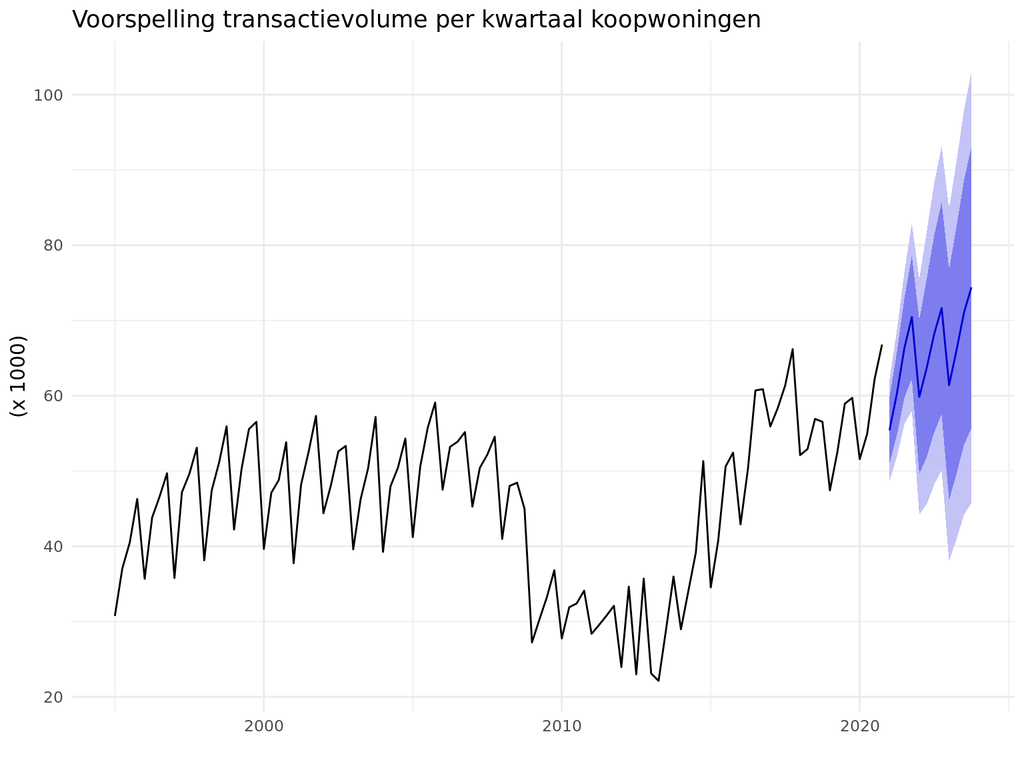

```r
# Fit the regression model and show projection
fit %>%
  forecast(h=12) %>%
  autoplot() +
  labs(
    title = "Voorspelling transactievolume per kwartaal koopwoningen",
    y = "(x 1000)",
    x = ""
    )
```

# 6 Conclusies

Er is in de media veel aandacht voor het woningtekort. Wanneer we kijken naar de prognose van het CBS lijkt er op termijn meer ruimte te ontstaan op de woningmarkt. De groei van de bevolking komt momenteel bijna geheel vanuit de migratie. Het geboorteoverschot is historisch laag - en zal gezien de vergrijzing ook niet snel stijgen. Hierdoor zal naar verwachting met name de druk op de grote steden verder zal toenemen.

De huizenprijzen reageren vertraagd op de ontwikkelingen in de economie. De belangrijkste indicatoren voor het voorspellen van de huizenprijzen zijn de prijzen (vorig kwartaal), de hypotheekrente, het BBP (1 jaar vertraagd) en de werkgelegenheid. Dit wordt zichtbaar in de leading indicators van het MARS model. Het model lijkt een goede basis vormen om voorspellingen te kunnen maken over de prijsontwikkelingen op de huizenmarkt. Hierbij moet wel rekening houden met de huidige unieke omstandigheden van de economie midden in de corona epidemie.

Het is in deze studie niet gelukt om een goed model te vinden voor het voorspellen van het aantal transacties. Opmerkelijk is dat ook het aantal huishoudens geen goede voorspelling geeft van de transactievolumes. Op basis van de beschikbare data geeft een autocorrelatie model (waarbij alleen gekeken worden naar het aantal transacties in de voorgaande perioden) de beste voorspelling.

# Referenties

CBS. (2016). *Indicatoren woningmarkt op groen*. Retrieved from https://www.cbs.nl/nl-nl/achtergrond/2016/16/indicatoren-woningmarkt-op-groen

CBS. (2020). *Huizenmarkt in beeld*. Retrieved from https://www.cbs.nl/nl-nl/visualisaties/huizenmarkt-in-beeld

Friedman, J. H. (2007). Multivariate Adaptive Regression Splines. *Annals of Statistics*. https://doi.org/10.1214/aos/1176347963

Groot, S., Vogt, B., Van der Wiel, K., & Van Dijk, M. (2018). *Oververhitting op de Nederlandse huizenmarkt?* Retrieved from https://www.cpb.nl/publicatie/oververhitting-op-de-nederlandse-huizenmarkt/CPB-Achtergronddocument-1jun2018-Oververhitting-op-de-nederlandse-huizenmarkt.pdf

Hanck, C., Martin, A., Alexander, G., & Schmelzer, M. (2020). *Introduction to Econometrics with R*. Retrieved from https://www.econometrics-with-r.org/index.html

Hyndman, R. J., & Athanasopoulos, G. (2018). *Forecasting: Principles and Practice*. Retrieved from https://otexts.com/fpp2/

Kenneth Gopal, Gerard van Leeuwen, David Omtzigt, T. K. en M. S.-F. (2020). *Prognose woningmarktmodel Socrates*. Retrieved from https://www.abfresearch.nl/publicaties/rapportage-socrates-2019/

Kuhn, M. (2020). *Caret: Classification and regression training*. Retrieved from https://github.com/topepo/caret/

Léon Groenemeijer, Kenneth Gopal, D. O. &. G. van L. (2020). *Vooruitzichten bevolking, huishoudens en woningmarkt, Prognose en Scenario’s 2020-2035*. Retrieved from https://www.rijksoverheid.nl/documenten/rapporten/2020/06/12/vooruitzichten-bevolking-huishoudens-en-woningmarkt-prognose-en-scenarios-2020-2035

MacKay, R. J., & Oldford, R. W. (2000). Scientific method, statistical method and the speed of light. *Statistical Science*, *15*(3), 254–278. https://doi.org/10.1214/ss/1009212817

Minister Wonen en Rijksdienst. (2016). *Staat van de woningmarkt 2016*. Retrieved from https://www.rijksoverheid.nl/binaries/rijksoverheid/documenten/rapporten/2016/10/31/rapport-staat-van-de-woningmarkt-2016/rapport-staat-van-de-woningmarkt-2016.pdf

Monitor koopwoningmarkt. (2020). *CBS Achtergronddocument*. Retrieved from https://www.cbs.nl/nl-nl/visualisaties/monitor-koopwoningmarkt

R Core Team. (2021). *R: A language and environment for statistical computing*. Vienna, Austria: R Foundation for Statistical Computing. Retrieved from https://www.R-project.org/

Research, A. (2020). *Primos - Bevolkingsprognose, Rapportage Primos*. Retrieved from https://www.abfresearch.nl/producten/prognoses/primos-bevolkingsprognose/

Trevor Hastie, S. M. D. from mda:mars by, & Thomas Lumley’s leaps wrapper., R. T. U. A. M. F. utilities with. (2020). *Earth: Multivariate adaptive regression splines*. Retrieved from http://www.milbo.users.sonic.net/earth/

Vogt, B., Kalara, N., & Voogt, B. (2018). *How do the Dutch Finance their Own House?* Retrieved from https://www.cpb.nl/sites/default/files/omnidownload/CPB-Background-Document-June2018-How-do-the-dutch-finance-their-own-house.pdf